# Mathematical Logic

Autumn 2025

## Socrates, again

- Premises
  - **P1**: all men are mortal,
  - **P2**: Socrates is a man,
- Conclusion

  then Socrates is mortal.

## Example

- Premises
  - **P1**: if the sum of the digits of a whole number is a multiple of \(3\), then the number is divisible by \(3\)
  - **P2**: if the last digit of a whole number is a \(5\) or a \(0\), then the number is divisible by \(5\).
- Conclusion

  The number \(2715\) is divisible by both \(3\) and \(5\).

## Terminology

- **Premise**: a statement assumed (or previously proved) true,
- **Conclusion**: logical result of two or more premises.
- **Valid**: conclusion follows from premises

  it is impossible for premises to be true and conclusion to be false
- **Invalid**: conclusion does not follow from premises.
- **Sound**: valid and all premises are true.
- **Unsound**: may be valid, but one or more premises may be false or faulty.

## Example: invalid

- Premises
  - **P1**: Plato is a great thinker,
  - **P2**: Plato is a man,
- Conclusion

  it follows that all humans are great thinkers.
- **P1** and **P2** only give information about Plato,
- we cannot generalise to *all* humans.

## EXample: invalid

- Premises
  - **P1**: if the sum of the digits of a whole number is a multiple of \(3\), then the number is divisible by \(3\)
  - **P2**: if the last digit of a whole number is a \(5\) or a \(0\), then the number is divisible by \(5\).
- Conclusion

  The number \(2710\) is divisible by both \(3\) and \(5\).
- **P2** can be applied because the last digit is \(0\),
- but **P1** does not apply because \(2 + 7 + 1 + 0 = 10\) is not a multiple of \(3\).

## Example: valid but unsound

- Premises
  - **P1**: all men are mortal,
  - **P2**: Socrates is a man,
- Conclusion

  then Socrates is mortal.
- One might argue that Socrates is a Lizard person, so **P1** is false.

## Example: valid but unsound

- Premises
  - **P1**: there are no even prime numbers.
- Conclusion

  then \(2\), being even, is not a prime number.
- \(2\), divisible by only \(1\) and itself, is clearly *even* and a *prime number*, so **P1** is false.

## Checking Deductive Logic

[interactive chart not shown]

## Mathematical proofs and programming

- Mathematical proofs rely on deductive logic,
- and, possibly more relevant, so does programming.
  - We can say a program is **valid** if it runs without crashing.
  - But its output is only **sound** if all the statements (premises) in the program are true
- Is it easy to check if a program is *valid*?

  Is it easy to check if a program is *sound*?

## Inductive Logic

- Seeks to find general principles from premises.
- Does not work to prove something purely from definitions
- Requires context (premises must align with reality).

## Discussion

- **P1**: If I work hard at university I’ll get a good grade
- **P2**: If I get a good grade I’ll get a good job
- **Con**: If I work hard at university, then I’ll get a good job

Is this good reasoning? Why?

- For maths nerds:
  - Premises: `(If A then B) AND (If B then C)`
  - Conclusion: `If A then C`

  is called *transitivity*.

## Problems

- **P1**
  - Inept teachers
  - Focus on the wrong things
  - Subjectivity
- **P2**
  - a “good job” may not require a degree at all, employers may view you as overqualified
  - lack of employment opportunities in your area of expertise
  - academically brilliant but lacking employability and commercial awareness
- **P1 + P2**
  - competition against more and more people with degrees

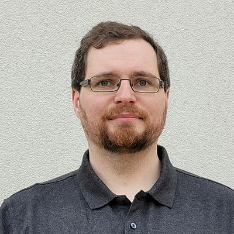

Dr Edward Longford

"*Nevertheless, you should still work hard at uni."* – Ed Longform

## Inductive keywords

- **Sound**: “correctly” formulated arguments
- **Unsound**: arguments contain logical flaws
- **Cogent**: arguments are *sound* and align with reality,
- **Uncogent**: premices might be sound, but they *do not align with reality*.

## Checking inductive logic

[interactive chart not shown]

## Problem Solving

- You may have been told

  “Programming is all about problem solving.”
- Break the problem down into small, easy to manage steps.
- These steps can be combined into a solution for a problem.

## Thinking about thinking

- “Meta”: beyond or self-referencing
- “Cognition”: the acquisition of knowledge and understanding through thought, experience, and senses
- “Metacognition”: exploring the way we acquire knowledge and understanding.
- Assisting us in applying that knowledge.
- Metacognition in philosophy typically involves
  - Ontology: theories of being and
  - Epistemology: theories of knowledge,

    but Educational Psychologists prefer the word metacognition

## The Dunning–Kruger effect

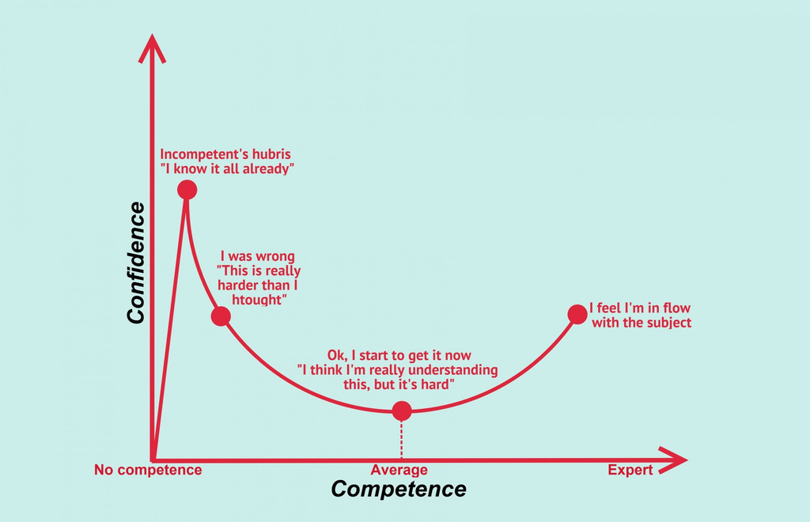

## Perception vs reality

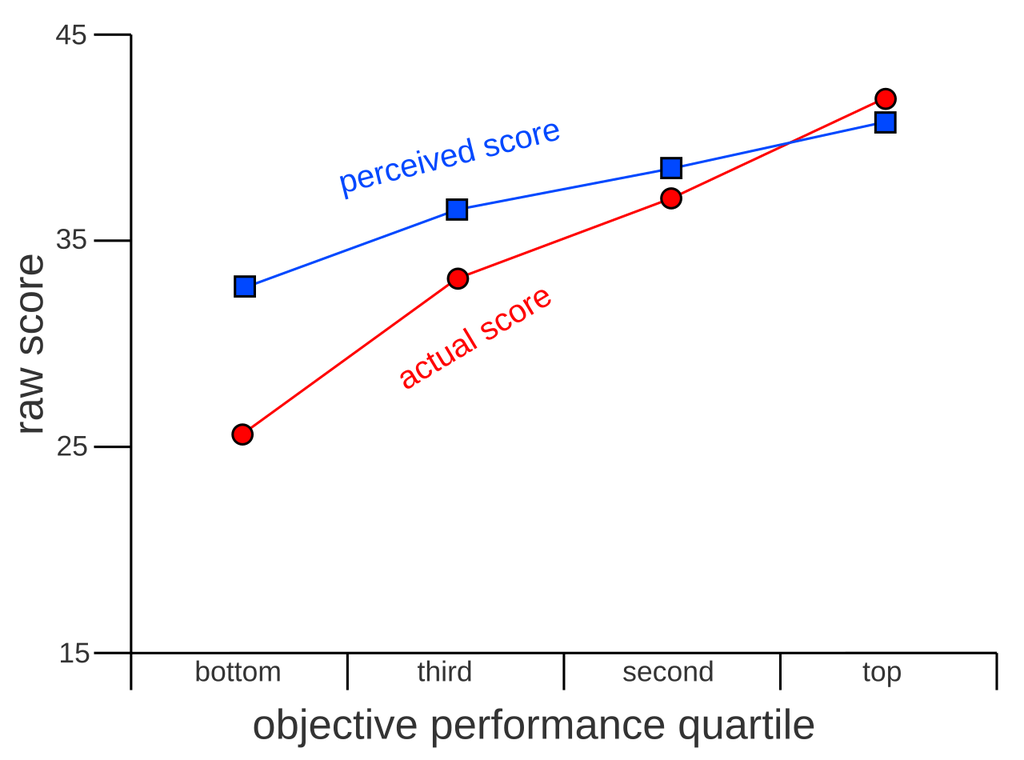

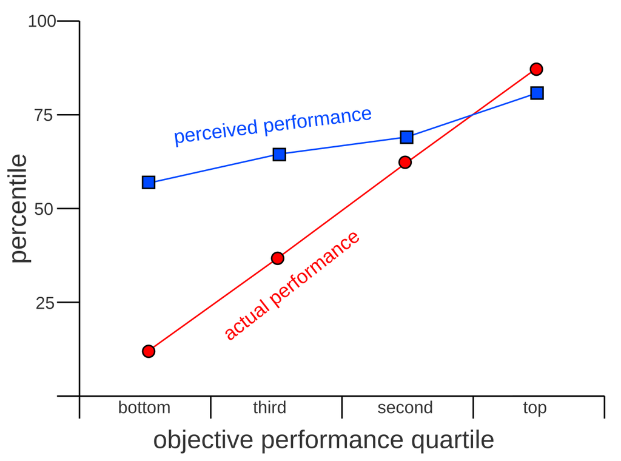

## Three levels of problem solving

1. **Application**
- able to *apply* a structured set of problem solving tools
1. **Understanding**
- knowing *Why* certain techniques are used,
- able to *improve upon* the basic set of tools.
- **Metacognition**
  - Able to see the problem from multiple perspectives and select the best tools for the job.
  - Able to design your own bespoke set of problem solving tools.

In the UK, after income tax and national insurance, who has the largest take-home salary?

- A couple, each of which earns \(21,000\),
- A single person earning \(40,000\)
- A single person earning \(46,200\)

## We need to ask questions…

What is \(0.1 + 0.2\)?

## Floating point problems

- Computers cannot handle numbers after the decimal point well.
- Stored using *scientific notation* using *binary*.
- Binary only has \(2\) as a prime factor,

  this is why we Ed likes base \(12 = 1 \cdot 12 = 2 \cdot 2 \cdot 3 = 3 \cdot 4\).
- See [https://0.30000000000000004.com/]

## Summary

- You can work your butt off at uni, get excellent grades and may still not get a good job at the end of it.
- Suppose you do get a high-paying job. Then the progressive tax system means you might end up with less take-home pay than othres earning less but in a different situation.
- Computers cannot even add up properly, so what’s the point in doingn computing in the first place?
- Don’t dispair, it’s more important to enjoy life and play than do nothing but work anyway!

## Which statement is more accurate?

- **A**: Bath Spa University is situated around the Bath area, it teaches Computing, Drama, and Advanced Zebra Studies.
- **B**: Bath Spa University teaches Computing mainly at its Locksbrook campus. It became a University in August 2005, having been previously known as as Dancing Penguin University College.
- **C**: Bath Spa University is a collection of buildings.
- **A**: Bath Spa University is situated around the Bath area, it teaches Computing, Drama, and Advanced Zebra Studies.
  - situated around the Bath area
  - it teaches Computing, **true**
  - [it teaches] Drama, **true**
  - [it teaches] Advanced Zebra Studies. **false**
- **B**: Bath Spa University teaches Computing mainly at its Locksbrook campus. It became a University in August 2005, having been previously known as as Dancing Penguin University College.
  - teaches Computing **true**
  - [teaches Computing] mainly at its Locksbrook campus **false**
  - It became a University in August 2005 **true**
  - previously known as Dancing Penguin University College. **false**
- **C**: Bath Spa University is a collection of buildings.
  - collection of buildings **true**

## Summary

- You can work your butt off at uni, get excellent grades and may still not get a good job at the end of it.
- Suppose you do get a high-paying job. Then the progressive tax system means you might end up with less take-home pay than othres earning less but in a different situation.
- Computers cannot even add up properly, so what’s the point in doingn computing in the first place?
- Don’t dispair, it’s more important to enjoy life and play than do nothing but work anyway!
- Oh, never mind. The world is burning!

## Today’s task

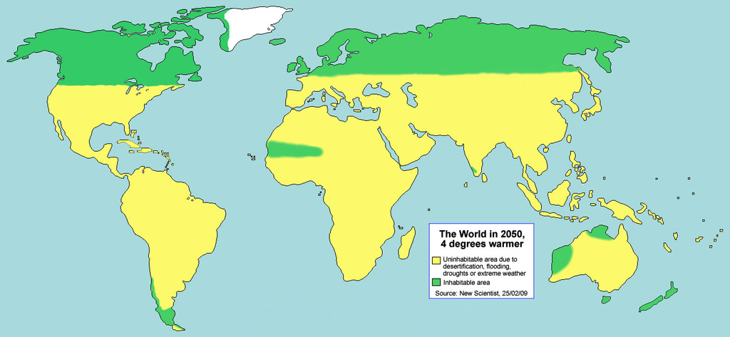

How do we solve this?